# Predicting Life Expectancy

Kalika Desai

December 9, 2025

## Step 1 - Attach Necessary Libraries

```r
library(tidyverse)
```

## Step 2 - Loading and Cleaning the Dataset

```r
df <- read.csv("~/Documents/GitHub Portfolio/Life Expectancy Project/Life-Expectancy-Data-Updated.csv")
df <- df %>% select(Alcohol_consumption, Polio, GDP_per_capita, Economy_status_Developed, Life_expectancy)
```

## Step 3 - Exploratory Data Analysis

### Quantitative Variables

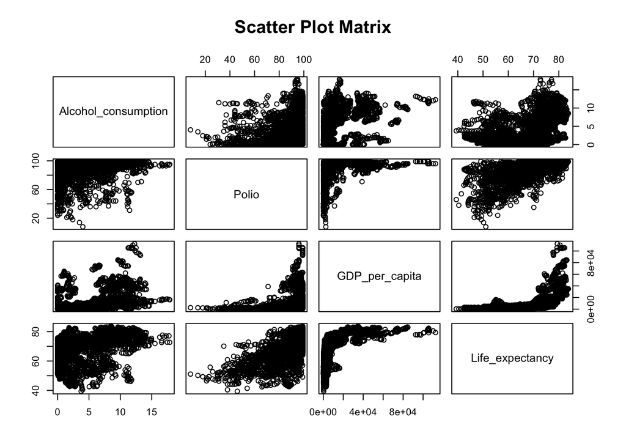

```r
pairs(df[, !names(df) %in% "Economy_status_Developed"], main = "Scatter Plot Matrix")
```

Firstly, we did an initial exploration of the data in order to understand the quantitative variables. The above figure is a scatter plot matrix that shows the relationships between all of the variables. When looking at polio, alcohol consumption, and life expectancy, they all have a seemingly linear relationships with each other. However, we can see that GDP per capita appears to be non-linear scatter plots. This was an early indication that we would need to perform a transformation on this variable.

```r
cor_mat <- cor(df[, !names(df) %in% "Economy_status_Developed"], method = "pearson", use = "complete.obs")
round(cor_mat, 3)
```

```
##                     Alcohol_consumption Polio GDP_per_capita Life_expectancy
## Alcohol_consumption               1.000 0.302          0.444           0.399
## Polio                             0.302 1.000          0.314           0.641
## GDP_per_capita                    0.444 0.314          1.000           0.583
## Life_expectancy                   0.399 0.641          0.583           1.000
```

Above is a table matrix of the Pearson correlations between variables. We can see that all of the correlations are positive, meaning each increase in the predictor values is associated with an increase in life expectancy. The strongest correlation is between polio vaccination coverage and life expectancy at 0.641. This shows that countries with higher vaccination rates tend to have a much higher life expectancy. The next highest correlation is between GDP per capita and life expectancy at 0.583. This shows that a wealthier country is correlated to a higher life expectancy. Both of these correlations intuitively make sense in context. Alcohol consumption, on the other hand, also has a positive relationship with life expectancy. This is slightly counterintuitive seeing as more alcohol is usually related to poor health. However, this reflects the societal nature of drinking tendencies and represents how wealthier countries tend to drink more alcohol. We can see the correlation between alcohol and GDP is moderately strong at 0.44, which supports this notion. It is not larger than 0.7 though, so multicollinearity is not a serious problem here.

### Categorical Variable

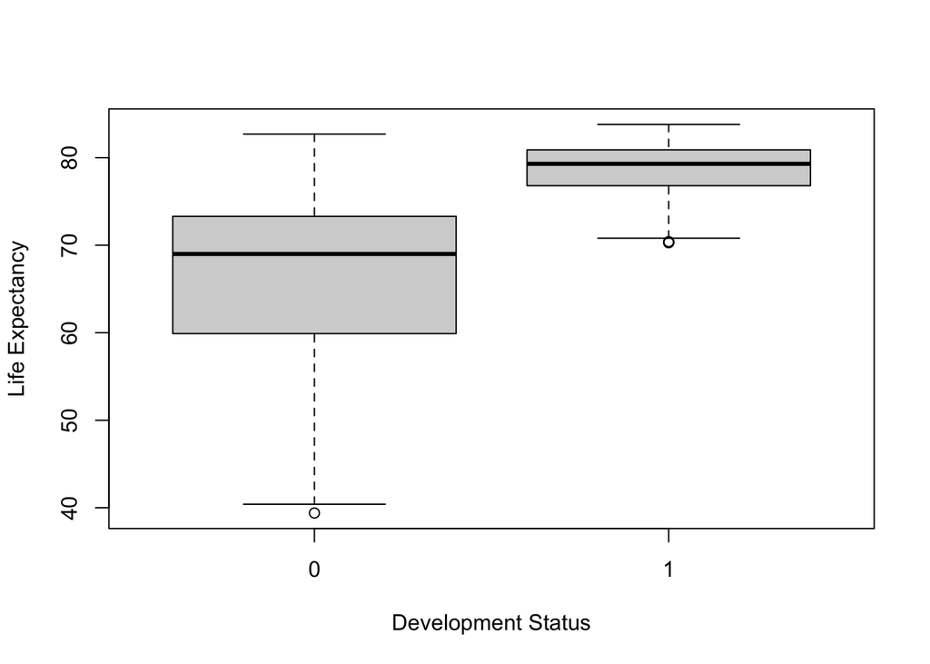

```r
boxplot(Life_expectancy ~ Economy_status_Developed, data = df,
        xlab = "Development Status",
        ylab = "Life Expectancy")
```

The above figure shows box plots of life expectancy, separated by development status. We can see from this plot that the median life expectancy for developed countries is much higher than that of developing countries. The data for developing countries has a larger spread, ranging from about 40 to 80 years. Alternatively, the developed countries are clustered around 70 to 80 years. This is an early indication that the baseline life expectancy for developed countries is higher than developing countries.

## Step 4 - Variable Transformation

As we discovered early, GDP per capita seemed to have a non-linear relationship with life expectancy. We explored this further by fitting a simple linear regression model to GDP. The figure below includes the diagnostic plots for this model. As we can see, there are large deviations from the theoretical line, and the residuals vs fitted plot there is a distinct pattern of residuals. These are indications that a linear model is not appropriate for this variable.

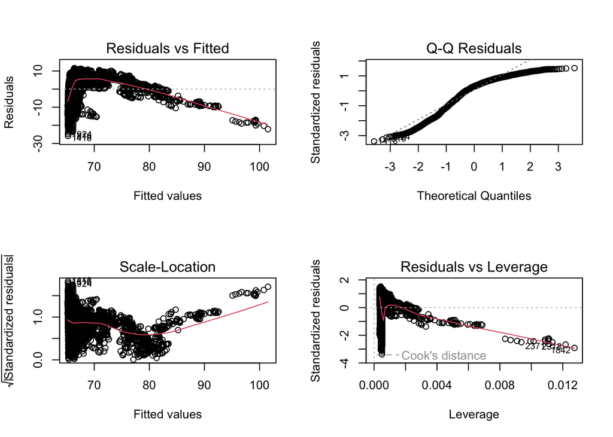

```r
gdp_model <- lm(Life_expectancy ~ GDP_per_capita, data = df)
par(mfrow = c(2, 2))
plot(gdp_model)
```

In order to fix this, we decided to perform a log transformation on the GDP variable. By performing this log transformation on GDP, we can see it has a much more linear relationship with life expectancy. This is seen in the figure below with the data points following more a linear path and showcasing the positive relationship between the variables. This is a good indication that a log transformation was the correct choice for this variable. This can be compared to Figure scatter plot matrix where the non-linear relationship between these variables is evident.

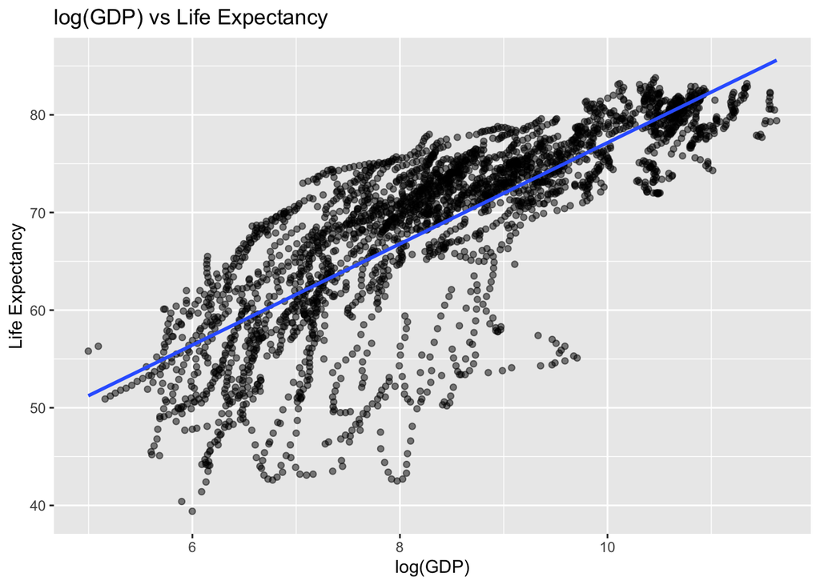

```r
ggplot(df, aes(log(GDP_per_capita), Life_expectancy)) +
  geom_point(alpha = 0.5) +
  geom_smooth(method = "lm", se = FALSE) +
  labs(x = "log(GDP)",
       y = "Life Expectancy",
       title = "log(GDP) vs Life Expectancy")
```

## Step 5 - Building Multiple Regression Models

Now that all of our variables are ready, we built three models to test against each other. Our variables are represented by $Y=\text{life expectancy}$, $x_1=\text{polio}$, $x_2=\text{alcohol consumption}$, $x_3=\text{log(GDP)}$, and $x_4=\text{development status}$. Model 1 is: $Y=\beta_0+\beta_1x_1+\beta_2x_2+\beta_3x_3+\epsilon$. This model only includes the three quantitative predictor variables. It suggests that there is no difference in life expectancy based on development. Model 2 is: $Y=\beta_0+\beta_1x_1+\beta_2x_2+\beta_3x_3+\beta_4x_4+\epsilon$. This has the addition of the dummy variable for development. In our data, a 1 is assigned to developed countries and a 0 is assigned to developing countries. We use this model to test if developed countries have a higher baseline life expectancy than developing countries. Model 3 is: $Y=\beta_0+\beta_1x_1+\beta_2x_2+\beta_3x_3+\beta_4x_4+\beta_5(x_1x_4)+\beta_6(x_2x_4)+\beta_7(x_3x_4)+\epsilon$. This model adds an interaction term between development and polio, alcohol, and GDP. This model suggests that the predictor variables affect countries differently based on development status.

In order to determine which model was the best fit for our data, we ran two simultaneous F-tests. The resulting Analysis of Variance table is below.

```r
# Model 1 - just quantitative variables
model1 <- lm(
  Life_expectancy ~ Polio + Alcohol_consumption + log(GDP_per_capita),
  data = df)
# Model 2 - categorical variable added
model2 <- lm(
  Life_expectancy ~ Polio + Alcohol_consumption + log(GDP_per_capita) + Economy_status_Developed, data = df)
# Model 3 - full interaction model
model3 <- lm(
  Life_expectancy ~ (Polio + Alcohol_consumption + log(GDP_per_capita)) * Economy_status_Developed,
  data = df)

anova(model1, model2, model3)
```

```
## Analysis of Variance Table
##
## Model 1: Life_expectancy ~ Polio + Alcohol_consumption + log(GDP_per_capita)
## Model 2: Life_expectancy ~ Polio + Alcohol_consumption + log(GDP_per_capita) +
##     Economy_status_Developed
## Model 3: Life_expectancy ~ (Polio + Alcohol_consumption + log(GDP_per_capita)) *
##     Economy_status_Developed
##   Res.Df   RSS Df Sum of Sq       F    Pr(>F)
## 1   2860 72892
## 2   2859 71350  1   1541.94 62.0483 4.722e-15 ***
## 3   2856 70974  3    376.63  5.0519  0.001718 **
## ---
## Signif. codes:  0 '***' 0.001 '**' 0.01 '*' 0.05 '.' 0.1 ' ' 1
```

The first test looked at Model 1 vs. Model 2. The objective of this test was to determine after accounting for polio, alcohol, and GDP, does life expectancy differ between developed and developing countries? Formally, $H_0:\beta_4=0$ and $H_1:\beta_4\ne0$. From the ANOVA table, F = 62.05 and p-value = 4.72e-15. Therefore, we can reject the null hypothesis and conclude that development status is a statistically significant variable. This indicates that it is true, the baseline life expectancies for developed and developing countries is different. This is further proof of our hypothesis based on the boxplots. Since the p-value is significant, therefore Model 2 is better than Model 1.

The second test looked at Model 2 vs. Model 3. This tested if the relationship between the predictor variables (polio, alcohol, GDP) and life expectancy is different between developed vs. developing countries. Formally, $H_0:\beta_5=\beta_6=\beta_7=0$ and $H_1:\text{at least one of these} \ne0$. From the ANOVA table, F = 5.05 and p-value = 0.0017. Therefore, we can reject the null hypothesis and conclude that at least one of the interaction terms is statistically significant. This shows evidence that the effect of the predictor variables on life expectancy differs depending on development status. Since the p-value is significant, Model 3 is better than Model 2. Therefore, going forward we chose Model 3 as the best fit for our data.

## Step 6 - Interaction Terms

To reiterate, our model is represented by the equation: $Y=\beta_0+\beta_1x_1+\beta_2x_2+\beta_3x_3+\beta_4x_4+\beta_5(x_1x_4)+\beta_6(x_2x_4)+\beta_7(x_3x_4)+\epsilon$. Here, there are three interaction terms between the dummy variable for development and the three quantitative predictor variables. The 3 figures below give a visual representation of why these interaction terms are included and significant.

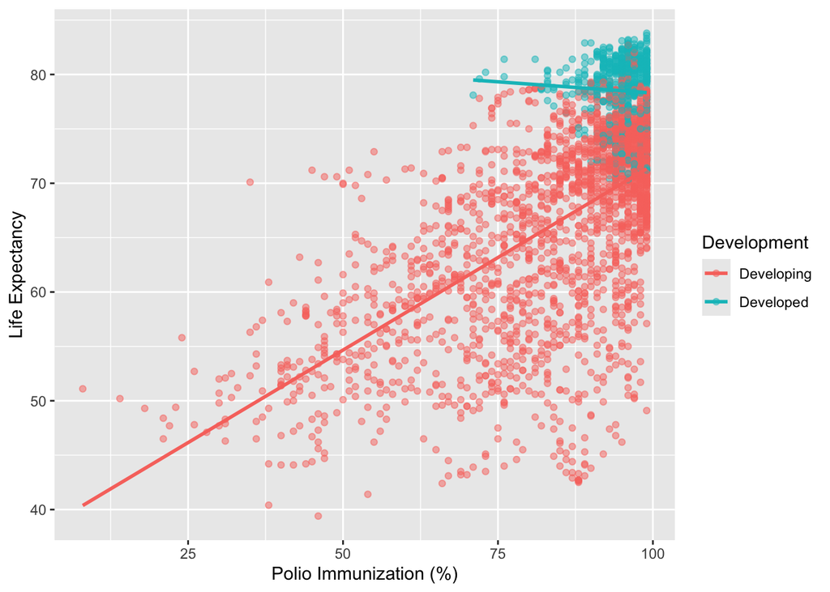

```r
df$Economy_status_Developed <- factor(
  df$Economy_status_Developed,
  levels = c(0, 1),
  labels = c("Developing", "Developed")
)

ggplot(df, aes(Polio, Life_expectancy,
               color = Economy_status_Developed)) +
  geom_point(alpha = 0.5) +
  geom_smooth(method = "lm", se = FALSE) +
  labs(x = "Polio Immunization (%)",
       y = "Life Expectancy",
       color = "Development")
```

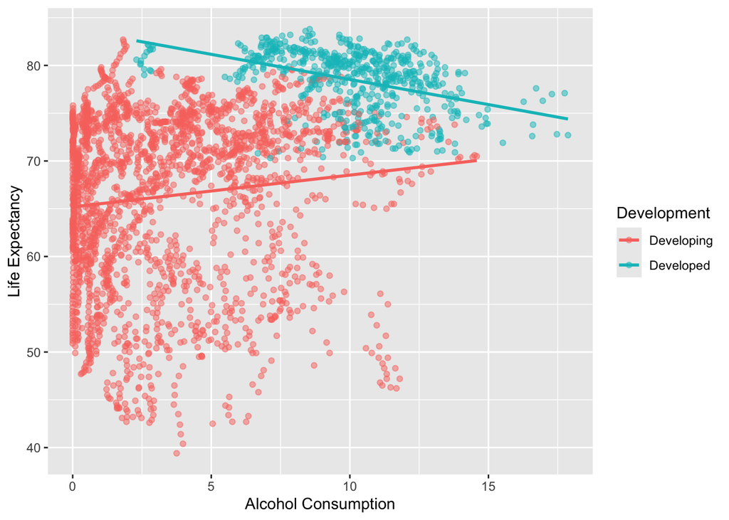

```r
ggplot(df, aes(Alcohol_consumption, Life_expectancy,
               color = Economy_status_Developed)) +
  geom_point(alpha = 0.5) +
  geom_smooth(method = "lm", se = FALSE) +
  labs(x = "Alcohol Consumption",
       y = "Life Expectancy",
       color = "Development")
```

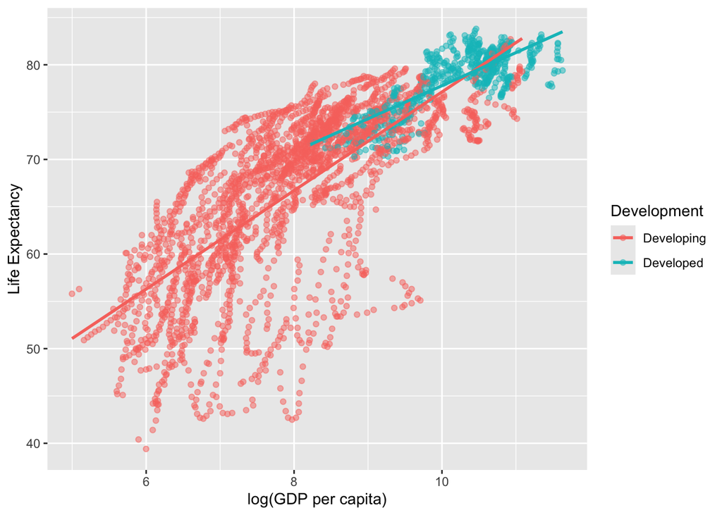

```r
ggplot(df, aes(log(GDP_per_capita), Life_expectancy,
               color = Economy_status_Developed)) +
  geom_point(alpha = 0.5) +
  geom_smooth(method = "lm", se = FALSE) +
  labs(x = "log(GDP per capita)",
       y = "Life Expectancy",
       color = "Development")
```

Each of these three plots show the relationship between life expectancy and the quantitative predictor variables, separated by development status. As we can see in all of the plots, the blue data points associated with the developed countries are all clustered near the tops of the graphs. This is similar to the boxplots, and shows that the baseline life expectancies in developed countries are higher than developing countries. The linear regression lines in each plot are different. This shows that the effect of each of the predictor variables differ according to development status. We can see that the red slopes, associated with developing countries, are very steep in comparison to the blue slopes (developed countries). While the blue slopes for polio immunization and alcohol consumption even appear to be negative. This indicates that as a country reaches development, the predictor variables could have less impact on a country’s life expectancy.

## Step 7 - Diagnostic Plots

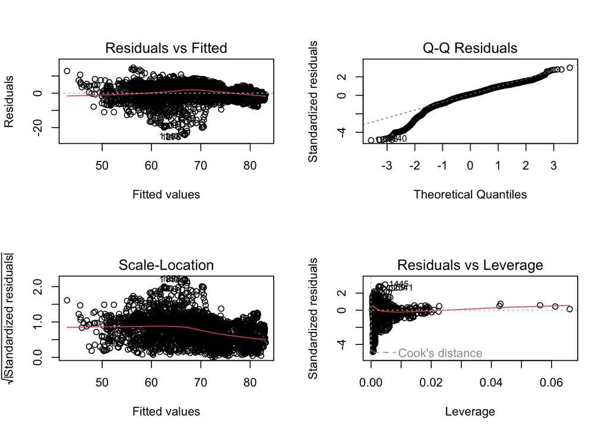

```r
par(mfrow = c(2, 2))
plot(model3)
```

## Step 8 - Confidence Intervals

We constructed 95% confidence intervals for each variable in our model. The results are shown in the table below.

```r
confint(model3)
```

```
##                                                   2.5 %     97.5 %
## (Intercept)                                  15.8865871 18.8295666
## Polio                                         0.1912503  0.2201592
## Alcohol_consumption                          -0.3742107 -0.2344757
## log(GDP_per_capita)                           3.9227771  4.3230692
## Economy_status_Developed                     14.3385926 38.7962600
## Polio:Economy_status_Developed               -0.2611554 -0.0573344
## Alcohol_consumption:Economy_status_Developed -0.2005963  0.1579618
## log(GDP_per_capita):Economy_status_Developed -1.4648329 -0.2256064
```

Using the results from this table, we are 95% confident of the following interpretations. First, we look at polio vaccination coverage. In developing countries, when there is a 1% increase in polio vaccination coverage, the increase in life expectancy is between 0.19 and 0.22 years. In developed countries, the interaction term is negative, which shows that the effect of polio vaccines on life expectancy is smaller than it is for developing countries. Second, we look at alcohol consumption. In developing countries, as alcohol consumption increases by 1 liter, life expectancy decreases by 0.23 to 0.37 years. In developing countries, increased alcohol consumption is associated with a decrease in life expectancy. However, the confidence interval for the interaction term contains 0. Therefore we cannot confidently say how alcohol affects developed countries differently. Now looking at GDP per capita. There is a strong positive effect in developing countries, meaning a higher GDP increases life expectancy. The interaction term is negative, meaning the effect GDP has on life expectancy in developed countries is smaller. Finally, the confidence interval for the development variable by itself shows that the baseline life expectancy for developed countries is 14.34 to 38.8 years higher than developing countries, without considering the interaction terms.

## Step 9 - Coefficient Interpretations

```r
summary(model3)
```

```
##
## Call:
## lm(formula = Life_expectancy ~ (Polio + Alcohol_consumption +
##     log(GDP_per_capita)) * Economy_status_Developed, data = df)
##
## Residuals:
##     Min      1Q  Median      3Q     Max
## -24.296  -2.338   0.503   3.346  14.896
##
## Coefficients:
##                                               Estimate Std. Error t value
## (Intercept)                                  17.358077   0.750456  23.130
## Polio                                         0.205705   0.007372  27.905
## Alcohol_consumption                          -0.304343   0.035632  -8.541
## log(GDP_per_capita)                           4.122923   0.102074  40.392
## Economy_status_Developed                     26.567426   6.236671   4.260
## Polio:Economy_status_Developed               -0.159245   0.051974  -3.064
## Alcohol_consumption:Economy_status_Developed -0.021317   0.091432  -0.233
## log(GDP_per_capita):Economy_status_Developed -0.845220   0.316001  -2.675
##                                              Pr(>|t|)
## (Intercept)                                   < 2e-16 ***
## Polio                                         < 2e-16 ***
## Alcohol_consumption                           < 2e-16 ***
## log(GDP_per_capita)                           < 2e-16 ***
## Economy_status_Developed                     2.11e-05 ***
## Polio:Economy_status_Developed                0.00220 **
## Alcohol_consumption:Economy_status_Developed  0.81566
## log(GDP_per_capita):Economy_status_Developed  0.00752 **
## ---
## Signif. codes:  0 '***' 0.001 '**' 0.01 '*' 0.05 '.' 0.1 ' ' 1
##
## Residual standard error: 4.985 on 2856 degrees of freedom
## Multiple R-squared:  0.7198, Adjusted R-squared:  0.7191
## F-statistic:  1048 on 7 and 2856 DF,  p-value: < 2.2e-16
```

To further prove the conclusions from the 95% confidence intervals, we will interpret the calculated coefficients and p-values from the model. These results are listed in the above table. From this table we can see that the estimates for polio and log(GDP) are positive, while alcohol consumption is negative. This shows that for developing countries, an increase in polio vaccinations and GDP per capita increase life expectancy, while increased alcohol consumption decreases life expectancy. The estimate for GDP is 4.123, which is large compared to the other variables. This shows that in developing countries, GDP per capita is the strongest predictor of life expectancy. Each of the p-values for these three variables is very close to 0, proving it’s statistical significance. For developed countries, we look at the interaction terms. The estimates are negative for each of the three interaction terms. This shows that effect of the predictors in developed countries is smaller. The p-value for alcohol is 0.82, which means it is not statistically significant. Therefore, the difference in effect of alcohol consumption between developing and developed countries is not significant. Lastly, $R^2=0.72$, indicating that about 72% of the variance in life expectancy is explained by the model. This is another indication that this model is a good fit for the data because the predictors capture most the variation.